# Measuring Stock Market Overreaction

By Rohan Gandhi

In a highly-cited paper by well known economists Richard Thaler and Werner De Bondt, they claim that stock markets generally overreact to bad news. This is seems somewhat intuitive. It is generally hard to price in non-qunatifiable factors into a model for stock valuation. Furthermore, the authors point out that investors tend to base their decisions off the most recent piece of evidence and not take into complete account all past data. This has the effect of resulting in Stock "overreaction", where investor's have knee jerk reaction to some news and cause the market to over-adjust. Thaler and De Bondt found that generally speaking, stocks that had a sudden tumble in price had better returns in the long than did stocks that had a jump in the price in reaction to good news. At this point, it must be easy to spot an opportunity here for the more patient investor. If stocks become under-valued when bad news hits, than the discerning investor can come in and snatch up some good-returning stocks at a discounted price. The result is that in the long-run, I could make more by putting my bets on what the market thinks are spoiled goods, while avoiding stocks that the market has identified as golden eggs, since this opinion will already be priced into the stock market price, thus making the price high and chance for future growth low. My plan is to take data on stock market reactions to Earnings data and see if there is a pattern. Earnings data is a report that companies issue 4 times a year (quarterly) to tell shareholders about various indicators about the business's performance, e.g. Revenue, Net Income, Cash At Hand, etc. It is also used to tell shareholders about any updates in the company's operation, as well as news about the company. A good earnings report can generate large stock market boosts for a company, and vice versa for poor earnings report.

## Step 1: Gather Data

Here we gather available data for the stocks we will use to analyze the overreaction hypothesis. For this project, I am using 2 python libraries to gather financial data: yfinance to get historical stock prices and yahoo_fin to get earnings release dates. Both are free, but there are some limitations on API calls, which will come up later.

```python
import yfinance as yf
import pandas as pd
import yahoo_fin.stock_info as si
import datetime
import numpy as np
import time
import matplotlib.pyplot as plt
from sklearn.linear_model import LinearRegression
from sklearn.metrics import mean_squared_error, r2_score
from sklearn.model_selection import train_test_split
import sklearn.model_selection as ms
import random
```

Below is a utility function that I will use later to convert datetime into strings so I can call rows from the S&P500 data file based on the string index. After I write the function, I read the csv file Historical Prices, which is a list of historical prices of the S&P 500 between the beginning of 2013 and the end 2019. I have intentionally limited my analyzing to these 6 years because it was a time of relative normality in the U.S. stock market, with steady growth year after year. This means that the cycles in the stock market won't have to be accounted for in this analysis. I got this data from the [Wall Street Journal.](https://www.wsj.com/market-data/quotes/index/SPX/historical-prices)

```python
def convertDate(dateObj):

    return dateObj.strftime("%m/%d/%y")


sp500 = pd.read_csv("HistoricalPrices.csv")
sp500 = sp500.set_index('Date')
sp500.loc['12/31/19']
```

```
 Open     3215.18
 High     3231.72
 Low      3212.03
 Close    3230.78
Name: 12/31/19, dtype: float64
```

Below is a function that gets data about a given stocks historical earnings reports and the stock market reaction to these reports. The stock argument is supposed to be the ticker of any stock. A ticker is just a short form of a stock name used on the stock market. The function first gets all the dates when the company released an earnings report from 2013 to 2018 using the yahoo_fin api. Then the function collects the stock market price before and after each earnings report. Earnings reports are usually released while the stock market is closed for the day, so gauging the reaction comes down to finding difference between the price of the given stock the morning before the report is released and the price of the stock the next day. Then the function gets the stock price a year out, so we can compare the long-term growth of the stock after the investors reacted to the earnings. Finally, the function returns a list of dictionaries, where each dictionary has the data about a particular earnings report, the stock market reaction, and long-term stock market data. Here is a list of variables that are returned in each dictionary:

Below the function definition, I run the function on the Apple stock (ticker: AAPL) just to demonstrate. It should be noted that the yfinance api has a restricted amount of calls per minute, so if the function doesn't work, there is a good chance it is because of the API.

```python
## This function will get the earnings and relevant data of a specified stock ticker

def getStockEarnings(stock):

    ## Get historical S&P500 prices

    sp500 = pd.read_csv("HistoricalPrices.csv")
    sp500 = sp500.set_index('Date')

    ## First get the earnings release history data for a certain stock
    ## Make a pandas DF from this data, convert earnings date to python Datetime format

    earningsHist = si.get_earnings_history(stock)
    earningsDf = pd.DataFrame.from_dict(earningsHist)
    earningsDf['trueDate'] = earningsDf['startdatetime'].apply(
    lambda x: datetime.datetime.strptime(x, "%Y-%m-%dT%H:%M:%S.000Z"))

    ## Then start collecting data for the Stock data coinciding with the earnings release
    ## We create API object for specific stock ticker, and we clean our DF to stay within
    ## selected data range

    tick = yf.Ticker(stock)
    df = []
    earningsDf = earningsDf[earningsDf["trueDate"] >= datetime.datetime(2013, 1, 1)]
    earningsDf = earningsDf[earningsDf["trueDate"] <= datetime.datetime(2018, 12, 31)]

    ## Go through every earnings date release

    for date in list(earningsDf.iterrows()):

        ## Now we go through the earnings data and get interval of stock data around Earnings date
        ## We take interval to account for weekends and holdays coinciding with the Earnings release

        trueDate = date[1]['trueDate']
        prices = tick.history(interval="1d", start= trueDate - datetime.timedelta(days=6),
                               end = trueDate + datetime.timedelta(days=6))
        before = None
        after = None
        pricesList = list(prices.iterrows())

        # Get prices around day of earnings and determine exactly
        # which dates precede and succeed day of earnings release
        # Get stock price at closing day before release
        # And get next day low

        for i in range(0, len(pricesList) - 1):
            if pd.to_datetime(pricesList[i][0], unit= "s").replace(hour=16) <= trueDate and pd.to_datetime(pricesList[i + 1][0], unit="s").replace(hour=9, minute=30) > trueDate:

                before = pricesList[i][0]
                beforeClose = pricesList[i][1][3]
                after = pricesList[i + 1][0]
                afterLow = pricesList[i+1][1][2]

        if before != None:

            ## Update DF with dates

            earningsDf.loc[date[0], 'before'] = before
            earningsDf.loc[date[0], 'after'] = after
            spTable = tick.history(interval = "1d", start=after,
                       end = after + datetime.timedelta(days = 1))


            ## Get stock data for one year out from the earnings date
            i = 0
            while(spTable.size <= 8):
                if True:
                    i = i + 1
                    if i > 10:
                        raise Exception("That aint it")
                    endDate = tick.history(interval = "1d", start= after + datetime.timedelta(days = 355 + i),
                           end = after + datetime.timedelta(days = 355 + i + 1))
                    spTable = pd.concat([spTable, endDate])

            ## Get stats for year range

            yrBefore = spTable.reset_index().Date.tolist()[0]
            yrAfter = spTable.reset_index().Date.tolist()[1]
            stockTable = tick.history(interval = "1d", start=yrBefore,
                       end = yrBefore + datetime.timedelta(days = 1))
            stockTable = pd.concat([stockTable, tick.history(interval = "1d", start=yrAfter,
                       end = yrAfter + datetime.timedelta(days = 1))])


            ## Put collected data in easy to read format and store in dictionary

            data = {"stock": stock, "date": trueDate, "before": before, "after": after,
                        "date" : trueDate,
                        "day_start": prices.loc[before]["Close"],
                        "day_end": prices.loc[after]["Low"],
                        "1yr_start": yrBefore,
                        "1yr_end": yrAfter,
                        "1yr_start_stock": stockTable.loc[yrBefore]["Low"],
                        "1yr_end_stock": stockTable.loc[yrAfter]["Close"],
                        "1yr_start_index": spTable.loc[yrBefore]["Low"],
                        "1yr_end_index":  spTable.loc[yrAfter]["Close"]}
            data["stock_drop"] = round(((data['day_end']-data['day_start'])/data['day_start']) * 100, 2)
            data["stock_diff"] = round(((data['1yr_end_stock']-data['1yr_start_stock'])/data['1yr_start_stock']) * 100, 2)
            data["index_diff"] = round(((sp500.loc[convertDate(yrAfter)][0]-sp500.loc[convertDate(yrBefore)][0])/sp500.loc[convertDate(yrBefore)][0]) * 100, 2)
            df.append(data)

    return df

df = getStockEarnings("AAPL")
for i in df:
    print(str(i) + "\n")
```

```
{'stock': 'AAPL', 'date': Timestamp('2018-11-01 16:30:00'), 'before': Timestamp('2018-11-01 00:00:00'), 'after': Timestamp('2018-11-02 00:00:00'), 'day_start': 53.59688949584961, 'day_end': 49.54733017499523, '1yr_start': Timestamp('2018-11-02 00:00:00'), '1yr_end': Timestamp('2019-10-24 00:00:00'),…

{'stock': 'AAPL', 'date': Timestamp('2018-07-31 16:30:00'), 'before': Timestamp('2018-07-31 00:00:00'), 'after': Timestamp('2018-08-01 00:00:00'), 'day_start': 45.735347747802734, 'day_end': 47.42256312074588, '1yr_start': Timestamp('2018-08-01 00:00:00'), '1yr_end': Timestamp('2019-07-23 00:00:00')…

{'stock': 'AAPL', 'date': Timestamp('2018-05-01 16:30:00'), 'before': Timestamp('2018-05-01 00:00:00'), 'after': Timestamp('2018-05-02 00:00:00'), 'day_start': 40.486305236816406, 'day_end': 41.611587255775355, '1yr_start': Timestamp('2018-05-02 00:00:00'), '1yr_end': Timestamp('2019-04-23 00:00:00'…

{'stock': 'AAPL', 'date': Timestamp('2018-02-01 16:30:00'), 'before': Timestamp('2018-02-01 00:00:00'), 'after': Timestamp('2018-02-02 00:00:00'), 'day_start': 40.00715255737305, 'day_end': 38.17585404141084, '1yr_start': Timestamp('2018-02-02 00:00:00'), '1yr_end': Timestamp('2019-01-24 00:00:00'),…

{'stock': 'AAPL', 'date': Timestamp('2017-11-02 16:30:00'), 'before': Timestamp('2017-11-02 00:00:00'), 'after': Timestamp('2017-11-03 00:00:00'), 'day_start': 39.94224548339844, 'day_end': 40.65740325880925, '1yr_start': Timestamp('2017-11-03 00:00:00'), '1yr_end': Timestamp('2018-10-25 00:00:00'),…

{'stock': 'AAPL', 'date': Timestamp('2017-08-01 16:30:00'), 'before': Timestamp('2017-08-01 00:00:00'), 'after': Timestamp('2017-08-02 00:00:00'), 'day_start': 35.511810302734375, 'day_end': 36.957845192286726, '1yr_start': Timestamp('2017-08-02 00:00:00'), '1yr_end': Timestamp('2018-07-24 00:00:00'…

{'stock': 'AAPL', 'date': Timestamp('2017-05-02 16:30:00'), 'before': Timestamp('2017-05-02 00:00:00'), 'after': Timestamp('2017-05-03 00:00:00'), 'day_start': 34.76717758178711, 'day_end': 34.00353366366508, '1yr_start': Timestamp('2017-05-03 00:00:00'), '1yr_end': Timestamp('2018-04-24 00:00:00'),…

{'stock': 'AAPL', 'date': Timestamp('2017-01-31 16:30:00'), 'before': Timestamp('2017-01-31 00:00:00'), 'after': Timestamp('2017-02-01 00:00:00'), 'day_start': 28.477956771850586, 'day_end': 29.80622912924036, '1yr_start': Timestamp('2017-02-01 00:00:00'), '1yr_end': Timestamp('2018-01-23 00:00:00')…

{'stock': 'AAPL', 'date': Timestamp('2016-10-25 16:30:00'), 'before': Timestamp('2016-10-25 00:00:00'), 'after': Timestamp('2016-10-26 00:00:00'), 'day_start': 27.608715057373047, 'day_end': 26.455332986314243, '1yr_start': Timestamp('2016-10-26 00:00:00'), '1yr_end': Timestamp('2017-10-17 00:00:00'…

{'stock': 'AAPL', 'date': Timestamp('2016-07-26 16:30:00'), 'before': Timestamp('2016-07-26 00:00:00'), 'after': Timestamp('2016-07-27 00:00:00'), 'day_start': 22.44866371154785, 'day_end': 23.86055448766261, '1yr_start': Timestamp('2016-07-27 00:00:00'), '1yr_end': Timestamp('2017-07-18 00:00:00'),…

{'stock': 'AAPL', 'date': Timestamp('2016-04-26 16:30:00'), 'before': Timestamp('2016-04-26 00:00:00'), 'after': Timestamp('2016-04-27 00:00:00'), 'day_start': 24.08546257019043, 'day_end': 22.0843066429416, '1yr_start': Timestamp('2016-04-27 00:00:00'), '1yr_end': Timestamp('2017-04-18 00:00:00'), …

{'stock': 'AAPL', 'date': Timestamp('2016-01-26 16:28:00'), 'before': Timestamp('2016-01-26 00:00:00'), 'after': Timestamp('2016-01-27 00:00:00'), 'day_start': 22.954551696777344, 'day_end': 21.427923161965243, '1yr_start': Timestamp('2016-01-27 00:00:00'), '1yr_end': Timestamp('2017-01-17 00:00:00'…

{'stock': 'AAPL', 'date': Timestamp('2015-10-27 16:30:00'), 'before': Timestamp('2015-10-27 00:00:00'), 'after': Timestamp('2015-10-28 00:00:00'), 'day_start': 26.18499183654785, 'day_end': 26.530159365917875, '1yr_start': Timestamp('2015-10-28 00:00:00'), '1yr_end': Timestamp('2016-10-18 00:00:00')…

{'stock': 'AAPL', 'date': Timestamp('2015-07-21 16:30:00'), 'before': Timestamp('2015-07-21 00:00:00'), 'after': Timestamp('2015-07-22 00:00:00'), 'day_start': 29.753469467163086, 'day_end': 27.760044209994067, '1yr_start': Timestamp('2015-07-22 00:00:00'), '1yr_end': Timestamp('2016-07-12 00:00:00'…

{'stock': 'AAPL', 'date': Timestamp('2015-04-27 16:30:00'), 'before': Timestamp('2015-04-27 00:00:00'), 'after': Timestamp('2015-04-28 00:00:00'), 'day_start': 30.060264587402344, 'day_end': 29.362303857804527, '1yr_start': Timestamp('2015-04-28 00:00:00'), '1yr_end': Timestamp('2016-04-18 00:00:00'…

{'stock': 'AAPL', 'date': Timestamp('2015-01-27 16:30:00'), 'before': Timestamp('2015-01-27 00:00:00'), 'after': Timestamp('2015-01-28 00:00:00'), 'day_start': 24.635360717773438, 'day_end': 26.0280704498291, '1yr_start': Timestamp('2015-01-28 00:00:00'), '1yr_end': Timestamp('2016-01-19 00:00:00'),…

{'stock': 'AAPL', 'date': Timestamp('2014-10-20 16:30:00'), 'before': Timestamp('2014-10-20 00:00:00'), 'after': Timestamp('2014-10-21 00:00:00'), 'day_start': 22.420866012573242, 'day_end': 22.76023334423824, '1yr_start': Timestamp('2014-10-21 00:00:00'), '1yr_end': Timestamp('2015-10-12 00:00:00')…
```

Now that we have our function for gather stock data, we need to figure out which stocks we will actually be using. Below, I have gathered up data about the composition of the S&P500 in 2013, so I can pick stocks from that list. I can't use the current list of stocks in the S&P500 because my data is historical and having those stocks would put bias in the data since all the stocks I would be analyzing would have survived and remained in the S&P500, and all the stocks that flunked would be ignored. It is hard to find data on the historical composition of the S&P500 so I am using a csv file from this website that keeps track of all the changes to the S&P500. I simply follow the changes until 2013, when I now have the S&P500 for 2013 arranged in a list called spHist. First I read in the CSV file, and format some of the date and time values. Then I put the stock tickers in a set, adding a ticker everytime the data says to and discarding any tickers the data says to discard.

```python
spHist = pd.read_csv("spHist.csv")

## Clean up dates in SP500 data

for index, row in spHist.iterrows():

    date = row['date']
    if ":" in date:
        spHist.loc[index,'date'] = datetime.datetime.strptime(date, "%Y-%m-%d %H:%M:%S")
    else:
        spHist.loc[index,'date'] = datetime.datetime.strptime(date, "%B %d, %Y")

spHist.sort_values('date', ascending=True, inplace=True)
```

```python
## Go through and get stocks in SP500

stocks = set()
for index, row in spHist.iterrows():

    if row['date'] < datetime.datetime(year=2013, month=1, day=1):

        if row['action'] == "added":

            stocks.add(row['ticker'])

        else:

            stocks.discard(row['ticker'])

len(stocks)
```

```
374
```

I am now ready to get the data for indvidual stocks. I go through the list of stocks and call the function from above on the individual stock ticker, allowing me to retrieve the necessary earnings data and store it in a dictionary called ticks.

**Important Note:** It should be noted that because of the yfinance API limit, you may have to repeat and try to retrieve data for some stocks over and over again. To get around this, I have already downloaded the necessary data using this method and then stored it in a CSV file. If you wish to, you may run it through this procedure. I have set it to retrieve 10 items, so it won't take too long, but the data will not be very informative either. Otherwise, run the cell below this.

**Additional Note:** Some data is just simply missing. Based on my own investigation, I have found the data to be MNAR, because the companies not included are mostly smaller, so this will affect the data. This means that the current analysis may not be entirely accurate, but it is still worth doing as a preface to a more conclusive study.

```python
## Get a 10 tickers for testing
ticks = {}
stocksList = list(stocks)
ticker = 0
while ticker < 10:
    print(stocksList[ticker])
    try:
        ticks[ticker] = getStockEarnings(stocksList[ticker])
        ticker += 1
    except IndexError:
        print("API call failed")
        time.sleep(20)
    except Exception:
        print("Data is missing")
        ticker += 1
```

```python
df = pd.read_csv("stocks.csv")
ticks = {"rawData": df.to_dict('records')}
```

## Step 2: Data Management

Now that we have the Raw Data, we can start arranging it for analysis. Below I gather the various dictionaries with earnings reports and put it into one big list called bigList. I then display the first 3 elements in the list.

```python
bigList = []
for ticker in ticks.keys():
    bigList = bigList + ticks[ticker]
bigList[0:3]
```

```
[{'Unnamed: 0': 0,
  'Unnamed: 0.1': 0.0,
  'Unnamed: 0.1.1': 0.0,
  'Unnamed: 0.1.1.1': 0.0,
  'stock': 'AON',
  'date': '2018-10-26 06:21:00',
  'before': '2018-10-25 00:00:00',
  'after': '2018-10-26 00:00:00',
  'day_start': 145.1341552734375,
  'day_end': 144.7954679737176,
  '1yr_start': '2018-10-26 00:00:00',
  '1yr_end': '2019-10-17 00:00:00',
  '1yr_start_stock': 144.79549795431922,
  '1yr_end_stock': '189.05523681640625',
  '1yr_start_index': 144.7954679737176,
  '1yr_end_index': 189.05517578125,
  'stock_drop': -0.23,
  'stock_diff': 30.57,
  'index_diff': 12.48},
 {'Unnamed: 0': 1,
  'Unnamed: 0.1': 1.0,
  'Unnamed: 0.1.1': 1.0,
  'Unnamed: 0.1.1.1': 1.0,
  'stock': 'AON',
  'date': '2018-07-27 06:29:00',
  'before': '2018-07-26 00:00:00',
  'after': '2018-07-27 00:00:00',
  'day_start': 142.60305786132812,
  'day_end': 138.7634620101104,
  '1yr_start': '2018-07-27 00:00:00',
  '1yr_end': '2019-07-18 00:00:00',
  '1yr_start_stock': 138.76341632878163,
  '1yr_end_stock': '192.12503051757807',
  '1yr_start_index': 138.7634467830008,
  '1yr_end_index': 192.12503051757807,
  'stock_drop': -2.69,
  'stock_diff': 38.46,
  'index_diff': 4.8},
 {'Unnamed: 0': 2,
  'Unnamed: 0.1': 2.0,
  'Unnamed: 0.1.1': 2.0,
  'Unnamed: 0.1.1.1': 2.0,
  'stock': 'AON',
  'date': '2018-05-04 07:09:00',
  'before': '2018-05-03 00:00:00',
  'after': '2018-05-04 00:00:00',
  'day_start': 134.72181701660156,
  'day_end': 131.8252868910579,
  '1yr_start': '2018-05-04 00:00:00',
  '1yr_end': '2019-04-25 00:00:00',
  '1yr_start_stock': 131.8252868910579,
  '1yr_end_stock': '174.69830322265625',
  '1yr_start_index': 131.82527190574342,
  '1yr_end_index': 174.6982879638672,
  'stock_drop': -2.15,
  'stock_diff': 32.52,
  'index_diff': 11.73}]
```

## Step 3: Data Exploration

Here we take a preliminary look at the data. I see what the average 1 year stock price growth is for all stocks after earnings releases, as well as the average for stocks that tanked more than 4% after earnings release. The average growth for stocks that tanked is marginally higher. I also calculated the change in the S&P500 as a frame of reference. The overall growth for the S&P500 was slower. At this point, the reader may notice the descrepancy between the stocks I'm tracking and the performance of the S&P500 index overall. S&P500 growth is much slower than the stocks I'm measuring. This is because the S&P500 weighs the stocks it keeps track of by market cap. Market cap is how much investors think the total company is worth. If the company is worth more, then the S&P500 weighs that particular stock more. This means that bigger, slower growing companies count more in their index. For me, I weigh all stocks equally, so riskier but faster-growing stocks of smaller companies drive my overall growth rate up.

```python
sumDrop = 0
sumDropSpec = 0
sumIndex = 0
sumIndexSpec = 0
nSpec= 0
n = len(bigList)

## Formatting

for i in range(0, len(bigList)):
    if str(type(bigList[i]['stock_diff'])) != "<class 'numpy.float64'>" and (str(type(bigList[i]['stock_diff'])) != "string"
    and str(type(bigList[i]['stock_diff'])) != "<class 'float'>"):
        print(type(bigList[i]['stock_diff']))
        bigList[i]['stock_diff'] = bigList[i]['stock_diff'][-1]

## Calculate Averages

for earn in bigList:

    sumDrop += earn['stock_diff']
    sumIndex += earn['index_diff']

    if earn['stock_drop'] < -4:
        sumDropSpec += earn['stock_diff']
        sumIndexSpec += earn['index_diff']
        nSpec += 1


sumDrop /= n
sumDropSpec /= nSpec
sumIndex /= n
sumIndexSpec /= nSpec

print("Stock Change: " + str(sumDrop))
print("Stock Change Below -4%: " + str(sumDropSpec))
print("Index Change: " + str(sumIndex))
print("Index Change Special: " + str(sumIndexSpec))
```

```
Stock Change: 15.660803571428563
Stock Change Below -4%: 17.046899696048634
Index Change: 9.848578869047602
Index Change Special: 9.982887537993921
```

Let's plot the relationship between a drop in the stock price after earnings release and the growth in the succeeding year. The resulting scatterplot looks pretty amorphus. So far, there doesn't seem to be as strong of a relationship as we hoped for. Let's keep poking around in the data and see if we can come up with anything.

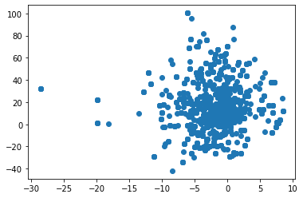

```python
bl = pd.DataFrame(bigList)

plt.scatter(bl["stock_drop"] , bl["stock_diff"] )
plt.show()
```

Here, I plot the relationship between the growth in the overall market and the growth for a particular stock. The result seems to suggest that the stock market growth carries a lot of momentum for all stocks listed on an exchange. This is probably due to underlying economic factors rather than any single given psychological factor. For example, when the economy does well, consumers will spend more thus driving growth and increasing profitability for businesses, which drives up employment which drivers up wages which drives up spending by consumers. The result is growth built in to the market. The graph below shows much more relationship between structural factors in the economy and 1 year growth rates by stocks.

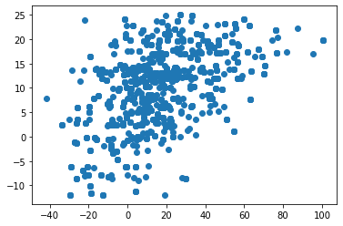

```python
plt.scatter(bl["stock_diff"] , bl["index_diff"] )
plt.show()
```

Here I check to see if there is any kind of correlation between a drop in the stock and the resulting growth over the following year standardized by the accompanying growth in the market. The result seems to indicate that when taking market momentum into account, stock drops seem to have little relationship with the resulting growth. This is a pretty dismal result and quite a blow for my quest, but it is the reality.

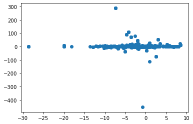

```python
plt.scatter(bl["stock_drop"] , bl["stock_diff"]/bl["index_diff"] )
plt.show()
```

## Step 4: Hypothesis Testing

```python
## Basic Linear Regression

bl = pd.DataFrame(bigList)

reg = LinearRegression().fit(bl["stock_drop"].to_numpy().reshape((-1, 1)),
                             bl["stock_diff"].to_numpy().reshape((-1, 1)))

X_train, X_test, y_train, y_test = train_test_split(bl["stock_drop"].to_numpy().reshape((-1, 1)),
                                                    bl["stock_diff"].to_numpy().reshape((-1, 1)),  shuffle=True, train_size=0.3)

reg = LinearRegression()
reg.fit(X_train, y_train)

print("coefficient: {0}, intercept: {1}".format(reg.coef_[0][0], reg.intercept_[0]))

predictions = reg.predict(X_test)
r2 = r2_score(y_test, predictions)
rmse = mean_squared_error(y_test, predictions, squared=False)

print('The r2 is: ', r2)
print('The rmse is: ', rmse)
```

```
coefficient: -0.21911388499492884, intercept: 14.928999885406474
The r2 is:  -0.004153452062381602
The rmse is:  22.50079249289678
```

Here I take my analysis further. I adjust the 1 year growth in stock price by standardizing it with the growth in the market at large. This means I am taking out the effect of market momentum in my analysis. The result highlights the lack of relationship even further. Now, with overall market momentum removed factored out, R^2 is at -.0003. At this point, there is no denying it. The relationship between stock market reactions and stock price growth for 1 year is non-existent. There is absolutely no evidence indicating that this relationship exists.

```python
## Basic Linear Regression

bl = pd.DataFrame(bigList)

reg = LinearRegression().fit(bl["stock_drop"].to_numpy().reshape((-1, 1)),
                             ((bl["stock_diff"]/bl["index_diff"])).to_numpy().reshape((-1, 1)))

X_train, X_test, y_train, y_test = train_test_split(bl["stock_drop"].to_numpy().reshape((-1, 1)),
                                                    (bl["stock_diff"]/bl["index_diff"]).to_numpy().reshape((-1, 1)),  shuffle=True, train_size=0.3)

reg = LinearRegression()
reg.fit(X_train, y_train)

print("coefficient: {0}, intercept: {1}".format(reg.coef_[0][0], reg.intercept_[0]))

predictions = reg.predict(X_test)
r2 = r2_score(y_test, predictions)
rmse = mean_squared_error(y_test, predictions, squared=False)

print('The r2 is: ', r2)
print('The rmse is: ', rmse)
```

```
coefficient: -0.3935993636188412, intercept: 3.0193627956752587
The r2 is:  -0.0003689066971899191
The rmse is:  23.469601212808403
```

## Concluding Remarks

The rather disappointing conclusion here seems to be that there is little correlation between a reaction in the market to earnings and the resulting growth. The overreaction hypothesis does not seem to hold here. It actually reflects rather well on market participants, showing that there is indeed a rational allocation of capital occurring in financial markets, where investors are able to see past the veil of bad news and buy and sell stocks when appropraite based on fundamental factors rather than helter-skelter thinking. The paper that was published by Thaler and De Bondt is itself a little under 40 years old, and so market overreaction is probably a well known phenomenon at this point among institutional investors espcially, so the market is able to find the appropriate equilibrium. Furthermore, earnings reports releases may not be the best time to gauge investor reaction. Reports often come with a lot of technical data, which keeps investors grounded in a more material analysis. There is plenty more room to go on and explore some more in this area. One thing could be to measure the result of stock market reactions to non-earnings news that only have an emotional factor. Another factor could be finding a more representative sample of the stock market. Still, this is disappointing as it closes the door on an investment idea, but there's always more to explore!